# Character preferences of different player groups in Stardew Valley

## Introduction

Stardew Valley is a videogame developed by ConcernedApe. It is a widely popular farming simulator which allows the player, among other things, to court and marry one of 12 possible spouses: 6 men, the bachelors, and 6 women, the bachelorettes (pictured below). The player's gender has no influence on which character can be married, and all of them are accessible from the start of the game, albeit some are easier to court than others due to their favourite gifts being easier to gather during early game. The characters are listed below, followed by a short description (source: [Stardew Valley Wiki](https://stardewvalleywiki.com)).

[figure not shown]

### Bachelors

- **Alex**: "Alex loves sports and hanging out at the beach. He is quite arrogant and brags to everyone that he is going to be a professional athlete. Is his cockiness just a facade to mask his crushing self-doubt? Is he using his sports dream to fill the void left by the disappearance of his parents? Or is he just a brazen youth trying to 'look cool'?"
- **Elliott**: "Elliott lives alone in a cabin on the beach. He is a writer who dreams of one day writing a magnificent novel. He is a sentimental romantic with a tendency to go off onto flowery, poetic tangents. When he can afford it, he enjoys a strong beverage at the Stardrop Saloon. Could a humble farmer such as yourself be the inspiration Elliott is looking for? There's only one way to find out..."
- **Harvey**: "Harvey is the town doctor. He's a little old for a bachelor, but he has a kind heart and a respected position in the community. He lives in a small apartment above the medical clinic, but spends most of his time working. You can sense a sadness about him, as if there's something he's not telling you..."
- **Sam**: "Sam is an outgoing, friendly guy who is brimming with youthful energy. He plays guitar and drums, and wants to start a band with Sebastian as soon as he has enough songs together. However, he does have a habit of starting ambitious projects and not finishing them. Sam is a little stressed about the impending return of his father, who has been away for years due to his line of work."
- **Sebastian**: "Sebastian is a rebellious loner who lives in his parents' basement. He is Maru's older half-brother, and feels like his sister gets all the attention and adoration, while he is left to rot in the dark. He tends to get deeply absorbed in computer games, comic books, and sci-fi novels, and will sometimes spend great lengths of time pursuing these hobbies alone in his room. He can be a bit unfriendly to people he doesn't know. Could a charming new farmer cultivate the wasteland of his heart? Who knows?"
- **Shane**: "Shane is a villager in Pelican Town who is often rude and unhappy, and suffers from depression and alcohol dependence. However, his attitude starts to change towards any player who chooses to befriend him. He works at JojaMart most days between 9am and 5pm, and after work he frequently spends his evenings in The Stardrop Saloon."

### Bachelorettes

- **Abigail**: "Abigail lives at the general store with her parents. She sometimes fights with her mom, who worries about Abigail's "alternative lifestyle". Her mom has the following to say: "I wish Abby would dress more appropriately and stop dyeing her hair blue. She has such a wonderful natural hair color, just like her grandmother did. Oh, and I wish she'd find some wholesome interests instead of this occult nonsense she’s into.” You might find Abigail alone in the graveyard, or maybe out in a rainstorm looking for frogs."
- **Emily**: "Emily loves to make her own clothing, but fabric can be difficult to come by in town. Among her favorite gifts are cloth and wool. Emily lives with her sister Haley, and together they care for their parents' home, who have been traveling the world for the past two years. She works with Gus, who employs her part-time at the saloon."
- **Haley**: "Being wealthy and popular throughout high school has made Haley a little conceited and self-centered. She has a tendency to judge people for superficial reasons. But is it too late for her to discover a deeper meaning to life? Is there a fun, open-minded young woman hidden within that candy-coated shell?"
- **Leah**: "Leah lives alone in a small cabin just outside of town. She loves to spend time outside, foraging for a wild meal or simply enjoying the gifts of the season. She's a talented artist with a large portfolio of work... yet she's too nervous to display it to the public. Maybe you can give her a little confidence boost?"
- **Maru**: "Growing up with a carpenter and a scientist for parents, Maru acquired a passion for creating gadgets at a young age. When she isn't in her room, fiddling with tools and machinery, she sometimes does odd jobs at the local clinic. Friendly, outgoing, and ambitious, Maru would be quite a lucky match for a lowly newcomer such as yourself... Can you win her heart, or will she slip through your fingers and disappear from your life forever?"
- **Penny**: "Penny lives with her mom, Pam, in a little trailer by the river. While Pam is out carousing at the saloon, Penny quietly tends to her chores in the dim, stuffy room she is forced to call home. She is shy and modest, without any grand ambitions for life other than settling in and starting a family. She likes to cook (although her skills are questionable) and read books from the local library."

As seen from their descriptions, most characters follow fairly common formulas (i.e. the jock, the popular girl, the videogame nerd, the scientist, the poet etc.), therefore I believed it would be interesting to see whether players of different gender, sexual orientation, and age differ in the ranking of these characters. I focused the analysis on the ranking specifically, instead of just allowing players to vote for their favourites, in order to better track changes in their choices and analyse which characters the groups dislike as well as which ones they prefer.

The data was collected by myself through a Google Form survey in July 2018. The form was diffused mainly through the website reddit.com, thus most of the responses are likely to come from the Stardew Valley community of that website. The users would rank the bachelors and the bachelorettes separately, each from #1 to #6, with #1 being the best. Then, the players had the option to choose their 3 favourite characters regardless of gender, and finally to provide information about their gender, orientation and age range.

In this notebook, the data collected is cleaned, analysed and visualised. Please note that the work here comprises the entirety of the analysis as it was carried out, if you would rather see only a selection of results highlights, follow [this link](https://public.tableau.com/profile/alepoptosis#!/vizhome/StardewValleySurveyResults/StardewValleyResults) to the Tableau Story for this analysis.

## Packages and functions

```python
import pandas as pd
import matplotlib.pyplot as plt
import seaborn as sns
import datetime as dt
import numpy as np

sns.set(context="talk", style="darkgrid", rc={"figure.facecolor":"white"})
sns.set_palette(sns.hls_palette(7, l=.55, s=.85))
```

```python
def get_comp(count):
    """given the count of a demographic, turns the absolute value into a percentage by
    adjusting for the total number of voters"""

    comp = round(count/n_votes*100, 2)
    return comp


def calc_points(boolean, group):
    """calculates the total points obtained by each candidate (group "b" = bachelors,
    group "be" = bachelorettes) for group indexed by boolean, then finds the
    average score by adjusting for group size and sorts from highest to lowest"""

    if group == "b":
        selection = sv.loc[boolean, "alex":"shane"]
    elif group == "be":
        selection = sv.loc[boolean, "abigail":"penny"]
    else:
        print("Please type 'b' for bachelors or 'be' for bachelorettes.")

    points = selection.sum().sort_values(ascending=False)
    average = round(points/len(selection), 2)
    return average


def comp_plot(df):
    """given a dataframe containing a demographics composition, produces a formatted
    barplot to visualise it"""

    plt.figure(figsize=(10,5))
    g = sns.barplot(x=df.index, y=df)
    plt.ylim(0, 100)
    g.set(ylabel="", yticklabels = ["{:,.0f}".format(x) + '%' for x in g.get_yticks()])
    plt.xticks(rotation = 90)
    plt.show()


def add_labels():
    """display bar values on a plotted chart"""

    for p in g.patches:
         g.annotate("%.2f" % p.get_height(), (p.get_x() + p.get_width() / 2., p.get_height()),
             ha='center', va='center', fontsize=11, color='gray', xytext=(0, 20),
             textcoords='offset points', rotation=90)


def double_plot(df_bachelors, df_bachelorettes, category, separate_legends=False):
    """given a df regarding bachelors and one regarding bachelorettes, it melts the
    dataframes by the category string provided and produces two formatted barplots
    in the same figure"""
    # uncomment the two commented sections below to display bar values on chart

    bachelors_long = df_bachelors.melt(id_vars=["bachelor"], var_name=category)
    bachelorettes_long = df_bachelorettes.melt(id_vars=["bachelorette"], var_name=category)

    plt.figure(figsize=(15,10))

    plt.subplot(1, 2, 1)
    g = sns.barplot(data=bachelors_long, x="bachelor", y="value", hue=category, order=bachelors_order)
    g.set(xlabel="", xticklabels=bachelors_labels, ylabel="Average score", yticks = np.arange(0,7,0.5))
    plt.xticks(rotation = 90)
    plt.ylim(0, 6)
    if separate_legends == True:
        g.legend_.set_title("")
    else:
        g.legend_.remove()
#     for p in g.patches:
#         g.annotate("%.2f" % p.get_height(), (p.get_x() + p.get_width() / 2., p.get_height()),
#          ha='center', va='center', fontsize=11, color='gray', xytext=(0, 20),
#          textcoords='offset points', rotation=90)

    plt.subplot(1, 2, 2)
    g = sns.barplot(data=bachelorettes_long, x="bachelorette", y="value", hue=category, order=bachelorettes_order)
    g.set(xlabel="", xticklabels=bachelorettes_labels, yticklabels=[], ylabel="", yticks = np.arange(0,7,0.5))
    plt.xticks(rotation = 90)
    plt.ylim(0, 6)
    g.legend_.set_title("")
#     for p in g.patches:
#         g.annotate("%.2f" % p.get_height(), (p.get_x() + p.get_width() / 2., p.get_height()),
#          ha='center', va='center', fontsize=11, color='gray', xytext=(0, 20),
#          textcoords='offset points', rotation=90)

    plt.show()

def dist_plot(order_list, color="r"):
    """given one of the two order lists (bachelor or bachelorette) and a plot
    colour (optional), returns a plot of the votes distribution for each candidate"""

    plt.figure(figsize=(20,10))
    for i in range(1,7):
        plt.subplot(2,3,i)
        g = sns.kdeplot(sv[order_list[i-1]], shade=True, color=color)
        g.set(xticks = np.arange(1,7,1))
        plt.ylim(0, 0.5)
    plt.show()
```

## Importing the data

```python
headers = ["time", "alex", "elliott", "harvey", "sam", "sebastian", "shane", # bachelors
           "abigail", "emily", "haley", "leah", "maru", "penny", # bachelorettes
           "overall_1", "overall_2", "overall_3", # top 3 choices overall
           "gender", "orientation", "age"] # player info

sv = pd.read_csv("datasets/sv_survey.csv", skiprows=1, names = headers, index_col=False)
sv.head()
```

|  | time | alex | elliott | harvey | sam | sebastian | shane | abigail | emily | haley | leah | maru | penny | overall_1 | overall_2 | overall_3 | gender | orientation | age |
| --- | --- | --- | --- | --- | --- | --- | --- | --- | --- | --- | --- | --- | --- | --- | --- | --- | --- | --- | --- |
| 0 | 2018/07/21 4:51:42 pm CET | #3 | #5 | #6 | #4 | #2 | #1 | #1 | #2 | #6 | #4 | #3 | #5 | NaN | NaN | NaN | Male | Pansexual | 19-29 |
| 1 | 2018/07/21 4:54:30 pm CET | #4 | #5 | #6 | #2 | #1 | #3 | #2 | #5 | #6 | #4 | #3 | #1 | NaN | NaN | NaN | Female | Pansexual | 19-29 |
| 2 | 2018/07/21 4:58:32 pm CET | #3 | #6 | #5 | #4 | #2 | #1 | #1 | #4 | #2 | #5 | #3 | #6 | NaN | NaN | NaN | Male | Bi-curious | 19-29 |
| 3 | 2018/07/21 5:18:33 pm CET | #1 | #5 | #4 | #6 | #3 | #2 | #4 | #3 | #6 | #1 | #5 | #2 | NaN | NaN | NaN | Female | Heterosexual | 19-29 |
| 4 | 2018/07/21 5:21:28 pm CET | #4 | #3 | #1 | #5 | #6 | #2 | #1 | #2 | #6 | #5 | #4 | #3 | NaN | NaN | NaN | Female | Heterosexual | 15-18 |

```python
sv.describe(include="all")
```

|  | time | alex | elliott | harvey | sam | sebastian | shane | abigail | emily | haley | leah | maru | penny | overall_1 | overall_2 | overall_3 | gender | orientation | age |
| --- | --- | --- | --- | --- | --- | --- | --- | --- | --- | --- | --- | --- | --- | --- | --- | --- | --- | --- | --- |
| count | 2800 | 2800 | 2800 | 2800 | 2800 | 2800 | 2800 | 2800 | 2800 | 2800 | 2800 | 2800 | 2800 | 2253 | 2240 | 2227 | 2775 | 2761 | 2765 |
| unique | 2765 | 6 | 6 | 6 | 6 | 6 | 6 | 6 | 6 | 6 | 6 | 6 | 6 | 12 | 12 | 12 | 23 | 35 | 7 |
| top | 2018/07/22 2:36:56 am CET | #6 | #2 | #1 | #4 | #1 | #6 | #1 | #5 | #6 | #1 | #6 | #3 | Leah | Leah | Leah | Male | Heterosexual | 19-29 |
| freq | 3 | 680 | 518 | 550 | 673 | 616 | 746 | 653 | 668 | 1053 | 919 | 706 | 557 | 423 | 436 | 329 | 1323 | 1634 | 1815 |

As it is possible to see from the table, while a number of votes has been cast in the survey, not the same number of people provided their gender, orientation or age. This is because while voting was compulsory, providing demographic info was not. This will be fixed in data cleaning by substituting all missing values with the "Prefer not to say" option. Similarly, data seems to be missing in the "overall" columns: this is because this voting option was not available from the beginning of the survey, but was added after some users had already voted. All other columns present values of the expected type and range.

## Data cleaning

### Timestamp

```python
sv["time"] = pd.to_datetime(sv["time"], format = "%Y/%m/%d %I:%M:%S %p %Z") # convert time of voting into datetime object
sv.head()
```

|  | time | alex | elliott | harvey | sam | sebastian | shane | abigail | emily | haley | leah | maru | penny | overall_1 | overall_2 | overall_3 | gender | orientation | age |
| --- | --- | --- | --- | --- | --- | --- | --- | --- | --- | --- | --- | --- | --- | --- | --- | --- | --- | --- | --- |
| 0 | 2018-07-21 16:51:42+02:00 | #3 | #5 | #6 | #4 | #2 | #1 | #1 | #2 | #6 | #4 | #3 | #5 | NaN | NaN | NaN | Male | Pansexual | 19-29 |
| 1 | 2018-07-21 16:54:30+02:00 | #4 | #5 | #6 | #2 | #1 | #3 | #2 | #5 | #6 | #4 | #3 | #1 | NaN | NaN | NaN | Female | Pansexual | 19-29 |
| 2 | 2018-07-21 16:58:32+02:00 | #3 | #6 | #5 | #4 | #2 | #1 | #1 | #4 | #2 | #5 | #3 | #6 | NaN | NaN | NaN | Male | Bi-curious | 19-29 |
| 3 | 2018-07-21 17:18:33+02:00 | #1 | #5 | #4 | #6 | #3 | #2 | #4 | #3 | #6 | #1 | #5 | #2 | NaN | NaN | NaN | Female | Heterosexual | 19-29 |
| 4 | 2018-07-21 17:21:28+02:00 | #4 | #3 | #1 | #5 | #6 | #2 | #1 | #2 | #6 | #5 | #4 | #3 | NaN | NaN | NaN | Female | Heterosexual | 15-18 |

### Votes

The votes as provided by Google Forms need to be cleaned by removing the "#" and turning the string into an integer.

```python
sv.loc[:,"alex":"penny"] = sv.loc[:,"alex":"penny"].replace("#","", regex=True) # remove "#" from votes
sv.loc[:,"alex":"penny"] = sv.loc[:,"alex":"penny"].apply(pd.to_numeric) # turn into integer
sv.head()
```

|  | time | alex | elliott | harvey | sam | sebastian | shane | abigail | emily | haley | leah | maru | penny | overall_1 | overall_2 | overall_3 | gender | orientation | age |
| --- | --- | --- | --- | --- | --- | --- | --- | --- | --- | --- | --- | --- | --- | --- | --- | --- | --- | --- | --- |
| 0 | 2018-07-21 16:51:42+02:00 | 3 | 5 | 6 | 4 | 2 | 1 | 1 | 2 | 6 | 4 | 3 | 5 | NaN | NaN | NaN | Male | Pansexual | 19-29 |
| 1 | 2018-07-21 16:54:30+02:00 | 4 | 5 | 6 | 2 | 1 | 3 | 2 | 5 | 6 | 4 | 3 | 1 | NaN | NaN | NaN | Female | Pansexual | 19-29 |
| 2 | 2018-07-21 16:58:32+02:00 | 3 | 6 | 5 | 4 | 2 | 1 | 1 | 4 | 2 | 5 | 3 | 6 | NaN | NaN | NaN | Male | Bi-curious | 19-29 |
| 3 | 2018-07-21 17:18:33+02:00 | 1 | 5 | 4 | 6 | 3 | 2 | 4 | 3 | 6 | 1 | 5 | 2 | NaN | NaN | NaN | Female | Heterosexual | 19-29 |
| 4 | 2018-07-21 17:21:28+02:00 | 4 | 3 | 1 | 5 | 6 | 2 | 1 | 2 | 6 | 5 | 4 | 3 | NaN | NaN | NaN | Female | Heterosexual | 15-18 |

As mentioned in the introduction, users ranked the characters from #1 to #6. However, if the ranks were used as is, this would show the highest scoring characters as having the lowest numeric totals. To avoid confusion, the ranks have therefore been converted to points, so that the characters with the most points have the highest votes. The new system will score the candidates from 1 point (lowest) to 6 points (highest).

```python
sv.loc[:,"alex":"penny"] = sv.loc[:,"alex":"penny"].replace({1 : 6, 2 : 5, 3 : 4, 4 : 3, 5 : 2, 6 : 1})
sv.head()
```

|  | time | alex | elliott | harvey | sam | sebastian | shane | abigail | emily | haley | leah | maru | penny | overall_1 | overall_2 | overall_3 | gender | orientation | age |
| --- | --- | --- | --- | --- | --- | --- | --- | --- | --- | --- | --- | --- | --- | --- | --- | --- | --- | --- | --- |
| 0 | 2018-07-21 16:51:42+02:00 | 4 | 2 | 1 | 3 | 5 | 6 | 6 | 5 | 1 | 3 | 4 | 2 | NaN | NaN | NaN | Male | Pansexual | 19-29 |
| 1 | 2018-07-21 16:54:30+02:00 | 3 | 2 | 1 | 5 | 6 | 4 | 5 | 2 | 1 | 3 | 4 | 6 | NaN | NaN | NaN | Female | Pansexual | 19-29 |
| 2 | 2018-07-21 16:58:32+02:00 | 4 | 1 | 2 | 3 | 5 | 6 | 6 | 3 | 5 | 2 | 4 | 1 | NaN | NaN | NaN | Male | Bi-curious | 19-29 |
| 3 | 2018-07-21 17:18:33+02:00 | 6 | 2 | 3 | 1 | 4 | 5 | 3 | 4 | 1 | 6 | 2 | 5 | NaN | NaN | NaN | Female | Heterosexual | 19-29 |
| 4 | 2018-07-21 17:21:28+02:00 | 3 | 4 | 6 | 2 | 1 | 5 | 6 | 5 | 1 | 2 | 3 | 4 | NaN | NaN | NaN | Female | Heterosexual | 15-18 |

### Gender

In order to ensure the voters could choose a gender they most identified with, the following options were provided: "Male", "Female", "Genderqueer/Non-binary", "Prefer not to say", and an open "Other" option. However, the last one turned out to be a terrible idea that will not be replicated in future surveys, as it generated a list of unique responses that cannot be properly classified. Instead, a closed "Other" option is preferable, and the survey has been amended to reflect this.

A list of all unique answers was generated: the answers "Non-binary" and "Genderqueer" were integrated in the provided option "Genderqueer/Non-binary", renominated "Non-binary" for brevity. All the other answers were classified as "Other".

```python
print("Unique values before cleaning:") # list of unique answers
print(sv.loc[:,"gender"].unique())

sv.loc[:,"gender"] = sv.loc[:,"gender"].replace("Genderqueer/Non-binary","Non-binary") # group the three terms under
sv.loc[:,"gender"] = sv.loc[:,"gender"].replace("Genderqueer","Non-binary")            # "Non-binary"

standard_genders = ["Male", "Female", "Non-binary", "Prefer not to say"] # standard answers

gender_bool = ~sv.loc[:,"gender"].isin(standard_genders) # replace all non-standard answers
sv.loc[gender_bool, "gender"] = "Other"                  # with "Other"

print("Unique values after cleaning:") # new list of unique answers
print(sv.loc[:,"gender"].unique())
```

```
Unique values before cleaning:
['Male' 'Female' 'Apache Attack Helicopter' 'Agendered' 'Non-binary'
 'Prefer not to say' 'StrogonoffSexual' nan 'Transmale' 'Genderqueer'
 "I don't identify as anything.  My biological sex is male."
 'attack chopper' 'Microwave and/or Mailbox' 'genderqueer/female'
 'genderfluid' 'I dont "identify". I AM female. ' 'Attack Helicopter'
 'Attack helicopter' 'Apache Helicopter' 'Genderqueer/Non-binary'
 'Transwoman' 'Genderfluid' "I'm female but I play as male character"
 'Trans Female']
Unique values after cleaning:
['Male' 'Female' 'Other' 'Non-binary' 'Prefer not to say']
```

### Orientation

The same problem that surfaced with the open "Other" option in the previous section presented itself here. In this case, the other options provided were "Asexual", "Homosexual", "Heterosexual", "Bisexual/Pansexual", and "Prefer not to say".

Like above, a list of all unique answers was generated: users who responded "Pansexual" and "Bisexual" were grouped with "Bisexual/Pansexual" users, since, while these identities are very distinct to some people, they are interchangeable for the scope of this survey, as both user groups would experience attraction to male and female candidates. All other answers were classified as "Other".

```python
print("Unique values before cleaning:") # list of unique answers
print(sv.loc[:,"orientation"].unique())

sv.loc[:,"orientation"] = sv.loc[:,"orientation"].replace("Pansexual","Bisexual") # group bisexual + pansexual
sv.loc[:,"orientation"] = sv.loc[:,"orientation"].replace("Bisexual","Bisexual/Pansexual") # rename category

# standard answers
standard_orientations = ["Asexual", "Homosexual", "Heterosexual", "Bisexual/Pansexual", "Prefer not to say"]

orientation_bool = ~sv.loc[:,"orientation"].isin(standard_orientations) # replace all non-standard answers
sv.loc[orientation_bool, "orientation"] = "Other"                       # with "Other"

print("Unique values after cleaning:") # new list of unique answers
print(sv.loc[:,"orientation"].unique())
```

```
Unique values before cleaning:
['Pansexual' 'Bi-curious' 'Heterosexual' 'Asexual' 'Bisexual' 'Homosexual'
 nan 'toucansexual' 'questioning' 'Biromantic Asexual' 'Queer' 'pansexual'
 'Prefer not to say' "i don't know" 'Not sure these days'
 'Gray ace, interested in women' 'I like tentacle monsters' 'Pan'
 'Bi with preference for men' '¯\\_(ツ)_/¯' "don't know" 'Pansexual '
 'Demisexual' 'Toaster Oven/Washer Machine' 'queer' 'Straight'
 "I believe in fluid sexuality, so I'm not comfortable with labels. Heteroflexible?"
 'Biromantic asexual' 'Homoromantic' 'I like girls' 'Don’t know yet'
 'ace lesbian' 'Panromantic Asexual' 'Slightly bi-curious'
 "I honestly don't know (yet)" 'pan/ace']
Unique values after cleaning:
['Bisexual/Pansexual' 'Other' 'Heterosexual' 'Asexual' 'Homosexual'
 'Prefer not to say']
```

### Age

The missing values in the Age column were replaced with a "Prefer not to say" label.

```python
print("Unique values before cleaning:") # list of unique answers
print(sv.loc[:,"age"].unique())

sv.loc[:,"age"].fillna("Prefer not to say", inplace=True) # substitute missing values with "Prefer not to say"

print("Unique values after cleaning:") # new list of unique answers
print(sv.loc[:,"age"].unique())
```

```
Unique values before cleaning:
['19-29' '15-18' '30-39' '40-49' '14 or under' '50 or over' nan
 'Prefer not to say']
Unique values after cleaning:
['19-29' '15-18' '30-39' '40-49' '14 or under' '50 or over'
 'Prefer not to say']
```

### Export clean dataset

Uncomment the following code block to export a clean version of the data to the dataset folder.

```python
# sv.to_csv("./datasets/sv_clean.csv", sep=',',index=False)
```

## Data analysis

### Total number of voters

```python
n_votes = len(sv)
print("Total number of voters:")
print(n_votes)
```

```
Total number of voters:
2800
```

### Demographics

The demographic composition of the voters.

```python
gender_comp = get_comp(sv.loc[:,"gender"].value_counts()) # percentage of voters per group

print("Percentage of voters per gender:")
print(gender_comp)
```

```
Percentage of voters per gender:
Male                 47.25
Female               46.18
Non-binary            3.50
Prefer not to say     1.54
Other                 1.54
Name: gender, dtype: float64
```

```python
orientation_comp = get_comp(sv.loc[:,"orientation"].value_counts())

print("Percentage of voters per orientation:")
print(orientation_comp)
```

```
Percentage of voters per orientation:
Heterosexual          58.36
Bisexual/Pansexual    24.07
Homosexual             9.00
Asexual                4.82
Other                  2.68
Prefer not to say      1.07
Name: orientation, dtype: float64
```

```python
age_comp = get_comp(sv.loc[:,"age"].value_counts())

print("Percentage of voters per age group:")
print(age_comp)
```

```
Percentage of voters per age group:
19-29                64.82
15-18                16.21
30-39                13.25
Prefer not to say     2.18
14 or under           1.64
40-49                 1.32
50 or over            0.57
Name: age, dtype: float64
```

### Average score per candidate

The average score per bachelor/bachelorette calculated across all voters.

```python
total_bachelors = sv.loc[:,"alex":"shane"].sum().sort_values(ascending=False) # sum of votes per candidate
total_avg_bachelors = round(total_bachelors/n_votes, 2) # average score per candidate

print("Average score per bachelor:")
print(total_avg_bachelors)

total_bachelorettes = sv.loc[:,"abigail":"penny"].sum().sort_values(ascending=False)
total_avg_bachelorettes = round(total_bachelorettes/n_votes, 2)

print("Average score per bachelorette:")
print(total_avg_bachelorettes)
```

```
Average score per bachelor:
sebastian    3.95
harvey       3.66
elliott      3.66
shane        3.33
sam          3.27
alex         3.14
dtype: float64
Average score per bachelorette:
leah       4.58
abigail    4.02
penny      3.65
emily      3.21
maru       2.86
haley      2.67
dtype: float64
```

### Average scores by gender

The average score per bachelor/bachelorette calculated across different genders. The "Prefer not to say" and "Other" options are not included as they do not provide insight into the voter's gender identity.

```python
male_bool = sv.loc[:,"gender"] == "Male" # select group of voters
female_bool = sv.loc[:,"gender"] == "Female"
enby_bool = sv.loc[:,"gender"] == "Non-binary"

bachelors_by_male = calc_points(male_bool, "b") # calculate average scores across group
bachelors_by_fem = calc_points(female_bool, "b")
bachelors_by_enby = calc_points(enby_bool, "b")

bachelors_gender = pd.concat([bachelors_by_male, bachelors_by_fem, bachelors_by_enby],
                             axis=1, sort=False) # create summary table
bachelors_gender.reset_index(inplace=True)
bachelors_gender.columns = ["bachelor", "men", "women", "non-binary"]

print(bachelors_gender)
```

```
    bachelor   men  women  non-binary
0     harvey  3.71   3.60        3.65
1  sebastian  3.68   4.18        4.15
2    elliott  3.60   3.71        3.78
3        sam  3.48   3.07        3.05
4       alex  3.35   2.94        2.69
5      shane  3.17   3.51        3.67
```

```python
bachelorettes_by_male = calc_points(male_bool, "be")
bachelorettes_by_fem = calc_points(female_bool, "be")
bachelorettes_by_enby = calc_points(enby_bool, "be")

bachelorettes_gender = pd.concat([bachelorettes_by_male, bachelorettes_by_fem, bachelorettes_by_enby],
                                 axis=1, sort=False)
bachelorettes_gender.reset_index(inplace=True)
bachelorettes_gender.columns = ["bachelorette", "men", "women", "non-binary"]

print(bachelorettes_gender)
```

```
  bachelorette   men  women  non-binary
0         leah  4.59   4.61        4.46
1      abigail  3.98   4.06        4.17
2        penny  3.79   3.56        3.20
3        emily  3.29   3.10        3.47
4        haley  2.87   2.48        2.33
5         maru  2.48   3.19        3.37
```

### Average scores by orientation

The average score per bachelor/bachelorette calculated across different orientations. The "Prefer not to say" and "Other" options are not included as they do not provide insight into the voter's orientation.

```python
het_bool = sv.loc[:,"orientation"] == "Heterosexual"
bi_bool = sv.loc[:,"orientation"] == "Bisexual/Pansexual"
homo_bool = sv.loc[:,"orientation"] == "Homosexual"
ace_bool = sv.loc[:,"orientation"] == "Asexual"

bachelors_by_het = calc_points(het_bool, "b")
bachelors_by_bi = calc_points(bi_bool, "b")
bachelors_by_homo = calc_points(homo_bool, "b")
bachelors_by_ace = calc_points(ace_bool, "b")

bachelors_orientation = pd.concat([bachelors_by_het, bachelors_by_bi, bachelors_by_homo, bachelors_by_ace],
                                  axis=1, sort=False)
bachelors_orientation.reset_index(inplace=True)
bachelors_orientation.columns = ["bachelor", "heterosexual", "bisexual", "homosexual", "asexual"]

print(bachelors_orientation)
```

```
    bachelor  heterosexual  bisexual  homosexual  asexual
0  sebastian          3.84      4.16        3.86     4.24
1    elliott          3.76      3.65        3.02     3.61
2     harvey          3.75      3.58        3.30     3.78
3        sam          3.35      3.10        3.37     3.08
4      shane          3.17      3.62        3.53     3.47
5       alex          3.13      2.89        3.91     2.81
```

```python
bachelorettes_by_het = calc_points(het_bool, "be")
bachelorettes_by_bi = calc_points(bi_bool, "be")
bachelorettes_by_homo = calc_points(homo_bool, "be")
bachelorettes_by_ace = calc_points(ace_bool, "be")

bachelorettes_orientation = pd.concat([bachelorettes_by_het, bachelorettes_by_bi,
                                       bachelorettes_by_homo, bachelorettes_by_ace],
                                       axis=1, sort=False)
bachelorettes_orientation.reset_index(inplace=True)
bachelorettes_orientation.columns = ["bachelorette", "heterosexual", "bisexual", "homosexual", "asexual"]

print(bachelorettes_orientation)
```

```
  bachelorette  heterosexual  bisexual  homosexual  asexual
0         leah          4.62      4.57        4.59     4.48
1      abigail          3.94      4.18        4.07     4.04
2        penny          3.80      3.46        3.38     3.54
3        emily          3.23      3.16        3.27     2.99
4        haley          2.72      2.60        2.67     2.47
5         maru          2.68      3.05        3.02     3.48
```

### Average scores by gender and orientation

The average score per bachelor/bachelorette calculated by comparing groups that are actually attracted to the gender of the spouses in question, e.g. average bachelor scores for men attracted to men versus women attracted to men. See the corresponding visualisation section for more information.

```python
mlm_bool = (sv.loc[:,"gender"] == "Male") & ((sv.loc[:,"orientation"] == "Homosexual") |
                                             (sv.loc[:,"orientation"] == "Bisexual/Pansexual"))
bachelors_by_mlm = calc_points(mlm_bool, "b")

wlm_bool = (sv.loc[:,"gender"] == "Female") & ((sv.loc[:,"orientation"] == "Heterosexual") |
                                               (sv.loc[:,"orientation"] == "Bisexual/Pansexual"))
bachelors_by_wlm = calc_points(wlm_bool, "b")

bachelors_plm = pd.concat([bachelors_by_mlm, bachelors_by_wlm],
                          axis=1, sort=False)
bachelors_plm.reset_index(inplace=True)
bachelors_plm.columns = ["bachelor", "men who love men", "women who love men"]

print(bachelors_plm)
```

```
    bachelor  men who love men  women who love men
0  sebastian              3.80                4.17
1       alex              3.76                2.92
2      shane              3.62                3.52
3     harvey              3.49                3.62
4        sam              3.31                3.04
5    elliott              3.02                3.72
```

```python
mlw_bool = (sv.loc[:,"gender"] == "Male") & ((sv.loc[:,"orientation"] == "Heterosexual") |
                                             (sv.loc[:,"orientation"] == "Bisexual/Pansexual"))
bachelorettes_by_mlw = calc_points(mlw_bool, "be")

wlw_bool = (sv.loc[:,"gender"] == "Female") & ((sv.loc[:,"orientation"] == "Homosexual") |
                                               (sv.loc[:,"orientation"] == "Bisexual/Pansexual"))
bachelorettes_by_wlw = calc_points(wlw_bool, "be")

bachelorettes_plw = pd.concat([bachelorettes_by_mlw, bachelorettes_by_wlw],
                              axis=1, sort=False)
bachelorettes_plw.reset_index(inplace=True)
bachelorettes_plw.columns = ["bachelorette", "men who love women", "women who love women"]

print(bachelorettes_plw)
```

```
  bachelorette  men who love women  women who love women
0         leah                4.60                  4.59
1      abigail                3.95                  4.18
2        penny                3.86                  3.47
3        emily                3.28                  2.95
4        haley                2.90                  2.69
5         maru                2.41                  3.11
```

### Average scores by age

The average score per bachelor/bachelorette calculated across different age groups. The "Prefer not to say" option is not included as it does not provide insight into the voter's age. Due to the low percentage of voters in the categories "under 14", "40-49", and "over 50", these have been incorporated with their nearest neighbour, and the labelling changed accordingly.

```python
under_18_bool = (sv.loc[:,"age"] == "14 or under") | (sv.loc[:,"age"] == "15-18")
range_19_29_bool = sv.loc[:,"age"] == "19-29"
over_30_bool = (sv.loc[:,"age"] == "30-39") | (sv.loc[:,"age"] == "40-49") | (sv.loc[:,"age"] == "50 or over")

bachelors_under_18 = calc_points(under_18_bool, "b")
bachelors_19_29 = calc_points(range_19_29_bool, "b")
bachelors_over_30 = calc_points(over_30_bool, "b")

bachelors_age = pd.concat([bachelors_under_18, bachelors_19_29, bachelors_over_30],
                           axis=1, sort=False)
bachelors_age.reset_index(inplace=True)
bachelors_age.columns = ["bachelor", "under 18", "19-29", "over 30"]

print(bachelors_age)
```

```
    bachelor  under 18  19-29  over 30
0  sebastian      3.81   3.99     3.90
1      shane      3.70   3.33     2.93
2     harvey      3.53   3.64     3.97
3        sam      3.47   3.24     3.14
4    elliott      3.39   3.65     4.04
5       alex      3.11   3.14     3.01
```

```python
bachelorettes_under_18 = calc_points(under_18_bool, "be")
bachelorettes_19_29 = calc_points(range_19_29_bool, "be")
bachelorettes_over_30 = calc_points(over_30_bool, "be")

bachelorettes_age = pd.concat([bachelorettes_under_18, bachelorettes_19_29, bachelorettes_over_30],
                              axis=1, sort=False)
bachelorettes_age.reset_index(inplace=True)
bachelorettes_age.columns = ["bachelorette", "under 18", "19-29", "over 30"]

print(bachelorettes_age)
```

```
  bachelorette  under 18  19-29  over 30
0         leah      4.35   4.62     4.73
1      abigail      4.15   4.03     3.83
2        penny      3.67   3.67     3.56
3        emily      3.33   3.15     3.31
4         maru      2.78   2.81     3.16
5        haley      2.72   2.72     2.42
```

### Overall score per candidate

The following data is extracted from the section of the survey that asked voters to pick their top three candidates independently of their gender. The votes have been weighed and summed to produce a total score for each spouse.

```python
overall_points = (sv["overall_1"].value_counts() * 3 +
                  sv["overall_2"].value_counts() * 2 +
                  sv["overall_3"].value_counts()).sort_values(ascending=False)

print("Weighed score per candidate:")
overall_points
```

```
Weighed score per candidate:
```

```
Leah         2470
Abigail      1827
Penny        1452
Sebastian    1346
Shane        1152
Harvey        966
Emily         906
Elliott       854
Haley         802
Alex          674
Maru          594
Sam           423
dtype: int64
```

## Visualisation and discussion

### Demographics visualisation

While not directly necessary towards understanding the preferences of each group, I plotted the demographic composition of the voters in order to highlight how some groups are strongly underrepresented in this survey, e.g. asexual players, non-binary players, or players in age ranges other than 19-29. While some of these categories are simply minorities in the general population, and therefore it is expected they represent a small percentage of the voters, it is still important to remember that the small sample size of those categories can influence the significance of the following results.

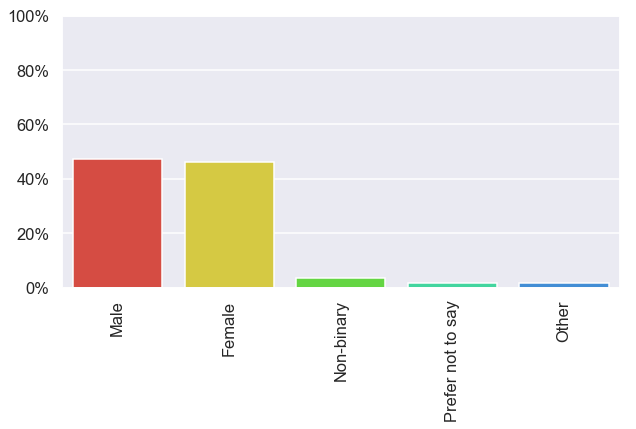

```python
comp_plot(gender_comp)
```

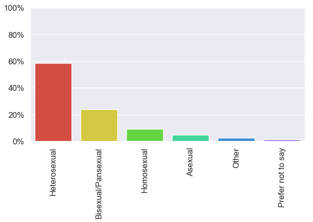

```python
comp_plot(orientation_comp)
```

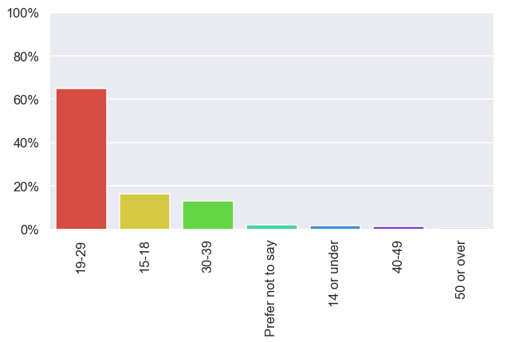

```python
comp_plot(age_comp)
```

### Results visualisation

```python
# bar order of all plots is based on whole population results to ease comparison

bachelors_order = ["sebastian", "harvey", "elliott", "shane", "sam", "alex"]
bachelors_labels = ["Sebastian", "Harvey", "Elliott", "Shane", "Sam", "Alex"]

bachelorettes_order = ["leah", "abigail", "penny", "emily", "maru", "haley"]
bachelorettes_labels = ["Leah", "Abigail", "Penny", "Emily", "Maru", "Haley"]
```

#### Average score per candidate results

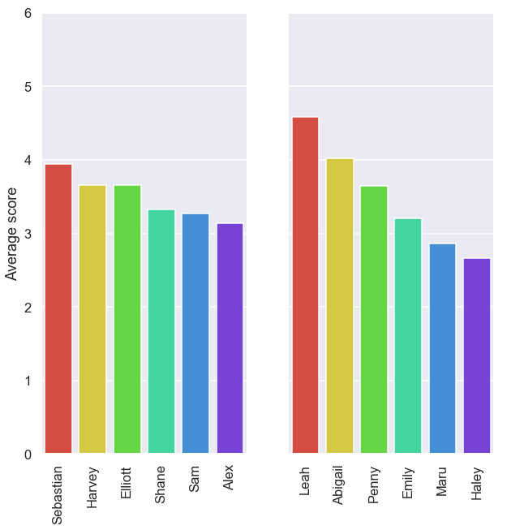

```python
plt.figure(figsize=(10,10))
plt.subplot(1, 2, 1)
g = sns.barplot(x=total_avg_bachelors.index, y=total_avg_bachelors)
g.set(ylabel="Average score", xticklabels=bachelors_labels)
plt.ylim(0, 6)
plt.xticks(rotation = 90)
# add_labels() # uncomment to display values on chart

plt.subplot(1, 2, 2)
g = sns.barplot(x=total_avg_bachelorettes.index, y=total_avg_bachelorettes)
g.set(xticklabels=bachelorettes_labels, yticklabels=[])
plt.xticks(rotation = 90)
plt.ylim(0, 6)
# add_labels() # uncomment to display values on chart

plt.show()
```

This plot shows the score of each bachelor and each bachelorette as ranked by all voters:

- Sebastian, the rebellious gamer, is the highest scoring bachelor;
- Alex, the arrogant jock, is the least appreciated bachelor;
- Leah, the shy artist, is the most loved bachelorette;
- Haley, the superficial beauty, is the least scoring bachelorette.

It is interesting to note that, while all bachelors have more or less similar scores, the differences between the bachelorettes are much more definite, possibly indicating a stronger consensus in the community regarding their ranking.

Before diving deeper in the preferences of the various demographics, I thought it would be useful to take a look at the score distribution for each candidate (below), to uncover any underlying trends that could have been masked by the use of average scores.

#### Votes distribution per candidate

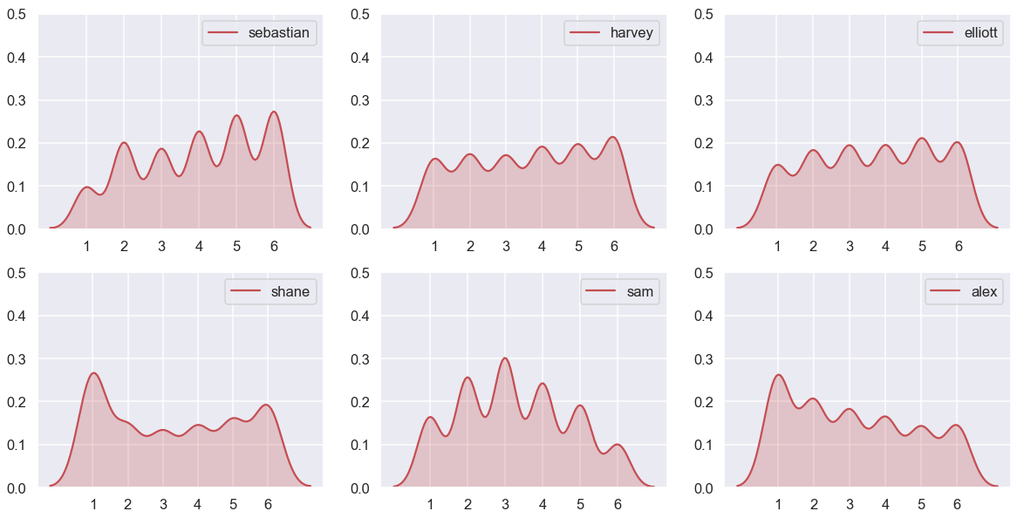

```python
dist_plot(bachelors_order, "r")
```

A clear example of how averages can mislead can be found here: Sam and Shane have almost the same average score (around 3.3), which could bring us to believe they are both not particularly liked nor disliked. However, when looking at their votes distribution we quickly realise this is not the case, since Sam shows to be most often ranked a 3, i.e. indeed neither liked nor disliked, while Shane's votes cluster around 1s (least favourite) and 6s (favourite), possibly indicating him as one of the more controversial character in the game. So even if their average score is similar, their votes distributions reveal that the way the community perceives them couldn't be more different.

Furthermore, it is interesting to note how none of the bachelors present any evident peaks, and instead show a more or less even distribution over all scores. This is likely an indication of how the voters' preferences are scattered across the entire selection rather than focused on one or two bachelors.

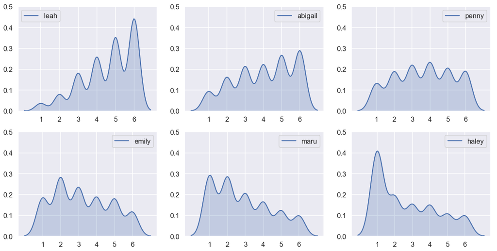

```python
dist_plot(bachelorettes_order, "b")
```

Unlike their male counterparts, the bachelorettes show much stronger trends and much more defined peaks, probably indicating a clearer consensus among the voters over their ranking. Their votes distribution, in fact, seems to correspond quite closely to their final average scores: having ordered the charts according to those, it is possible to see the peaks moving from the very right with Leah, the top bachelorette, then disappearing into a more even distribution with the candidates ranked in the middle, i.e. Penny and Emily, and then move to the very left with the bottom scoring one, Haley.

#### Average score by gender results

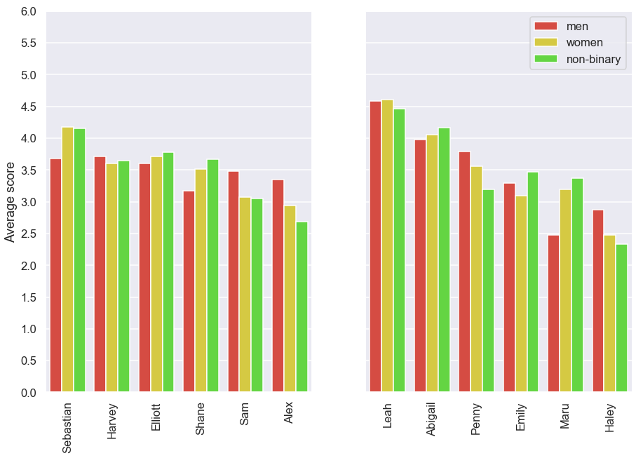

```python
double_plot(bachelors_gender, bachelorettes_gender, "gender")
```

The first deeper dive into the voter's preferences revolves around the different gender groups.

- Sebastian, the top bachelor overall, seems to be less liked by male-identifying players, with their appreciation going more towards lower-scoring characters like Sam and Alex. On the other hand, women and non-binary players present the exactly opposite trend;
- For the bachelorettes, the top two candidates, Leah and Abigail, remain everyone's favourite regardless of gender. However, the bottom of the ranking changes more dramatically, with Maru being significantly more popular with non-male players. If it were for male players, in fact, Maru would be the lowest scoring bachelorette, with Haley as the second-lowest.

Overall, women and non-binary players present similar trends, which tend to directly opposite those from male-identifying players for most candidates, except for a few popular choices like Harvey, Elliott, Leah or Abigail.

#### Average score by orientation results

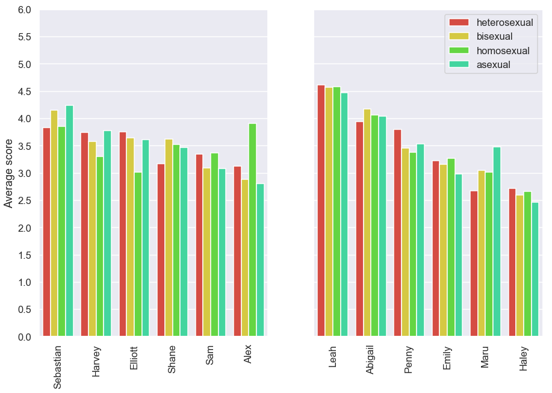

```python
double_plot(bachelors_orientation, bachelorettes_orientation, "orientation")
```

This chart refers to the preferences of voters of different orientations.

- The most obvious outlier among the bachelors is Alex, who goes from being the lowest scoring candidate to the highest scoring one among homosexual players, reaching an average score of almost 4 out of 6. On the other hand, Elliott, who is the most unpopular in the homosexual group, regains votes among heterosexual players;
- For the bachelorettes, the more drastic change when looking into player orientation is Maru's popularity among asexual players, possibly due to the less sexualised nature of her character and avatar. Oppositely, Maru is less popular among heterosexual players than Haley, which again challenges the original total ranking.

It is interesting to observe how the preferences of bisexual and asexual players seem to align in most cases, while those of homosexual and heterosexual player frequently clash. However, it is important to remember how, when talking about homosexual and heterosexual players, we are respectively grouping gay men and gay women, as well as straight men and straight women. For each pair of groups, one would not be attracted to the gender of the candidates in question, which could influence the results. Therefore, the following section delves even deeper into the preferences of these groups by:

- comparing the bachelor scores of men who love men (gay/bisexual/pansexual men) and women who love men (straight/bisexual/pansexual women),
- and the bachelorette scores of men who love women (straight/bisexual/pansexual men) and women who love women (gay/bisexual/pansexual women).

#### Average score by gender and orientation results

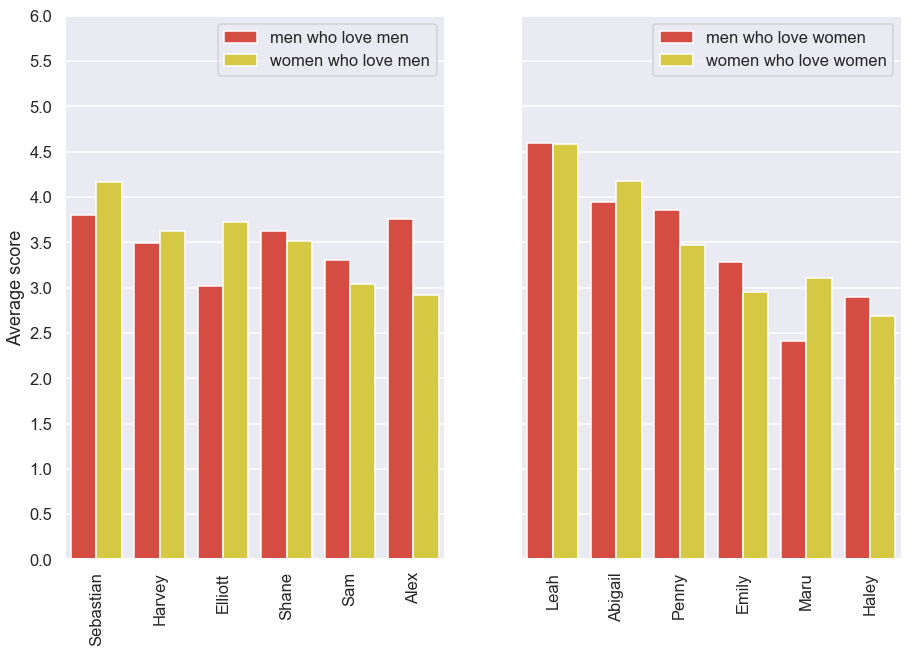

```python
double_plot(bachelors_plm, bachelorettes_plw, "group", separate_legends=True)
```

- When looking at the bachelors, the high score awarded to Alex by homosexual players appears to be the work of mostly gay players, as they rank him as high as Sebastian, the overall top bachelor;
- On the other hand, Elliott, who in the previous chart appeared to be preferred by heterosexual players, is shown here to be very appreciated by straight and bisexual women, while being the least favourite of gay/bi men;
- While the bachelorette ranking, once again, sees more agreement between the groups, there is a slight difference between straight men and gay women, as women prefer Maru more than men, who instead rank her at the bottom instead of Haley.

#### Average score by age results

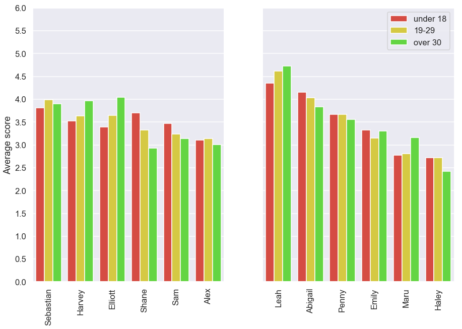

```python
double_plot(bachelors_age, bachelorettes_age, "age")
```

This chart represents the preferences of voters of different age groups.

- Elliot and Harvey are the top choices of players over 30, surpassing even the overall top bachelor, Sebastian. The popularity of these two characters, however, decreases with younger players;
- Shane follows the opposite trend: he is the second most popular bachelor among players under 18, but his popularity decreases more and more as players age, until he reaches the bottom of the ranking among players over 30;
- The bachelorettes present less unusual spikes. Leah, who is already the top bachelorette, reaches even higher scores among older players, who seem to also be fonder of Maru more than younger players. Otherwise, the age-based classification follows the overall scores quite closely.

The way players of different age groups votes is partly reflective of how the characters are presented in the game. Characters like Sebastian, Sam and Abigail still live with their parents, do not have jobs and are generally perceived as younger, even if they do not have an official age, and thus attract younger players who identify with them. On the other hand, Harvey, Elliott, Leah or Emily live on their own, most of them have jobs, and are generally perceived as more adult than the rest of the candidates, possibly making them more appealing to an older audience.

#### Overall score per candidate results

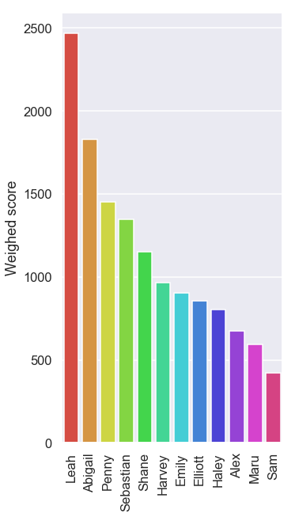

```python
sns.set_palette(sns.hls_palette(12, l=.55, s=.85))

plt.figure(figsize=(5,10))
g = sns.barplot(x=overall_points.index, y=overall_points)
g.set(ylabel="Weighed score")
plt.xticks(rotation = 90)
plt.show()
```

Finally, the last chart shows a weighed ranking of all the candidates, regardless of their gender. While I didn't find it necessary to filter the results by demographic here, I believe it provides an interesting overview of the preferences of the entire community. It is especially curious to see how none of the bachelors make it into the top three, with Leah, Abigail and Penny, the top three bachelorettes, trumping Sebastian, the top bachelor.

## Conclusion

The preferences expressed by this sample of Stardew Valley players, while representative only of a fraction of the gaming community, could be useful to those interested in game development to aid the design of non-playable characters. In fact, if different tropes did indeed attract different demographics, this could be used to target specific player groups of interest by creating characters that would appeal to them.

A factor which could have influenced the outcome of this survey is character development, or more specifically the dialogues through which the candidates in the game relate to the player. The characters that players prefer the most, in fact, could simply be those with better developed stories or more interesting dialogue options, altering a possible preference of a demographic for one trope or another. Furthermore, less dedicated players could ignore characters which are more difficult to court in early game, thus never interacting with those enough to rank them positively, or even negatively, again possibly influencing their choices. To carry out a similar study on a larger scale, without the influence of dialogue or in-game mechanics, and independently of any specific community, a survey could be designed to include newly created characters, along with an avatar and a description of their personality, to see whether these results can be replicated outside of the Stardew Valley environment. This would allow to survey player's first impressions of characters, and could possibly be applied to games other than farming/dating simulators.

In the meantime, the survey that generated this data is still open. If you want to participate to weight in on future updates, [click here](https://forms.gle/bjNcoxpgdPpQv4x76).